# Respiratory Virus Situation Report (AZ, CO, NM, UT) — January 22, 2026

[figure not shown]

[figure not shown]

[figure not shown]

#### COVID

The current COVID epidemic trend (based on data reported through 1/13/2026) is **declining** for Colorado, Arizona, and New Mexico and is not currently estimated for Utah. The weekly percentage of ED visits diagnosed with COVID was **low** for Colorado and New Mexico and **very low** for Arizona and Utah.

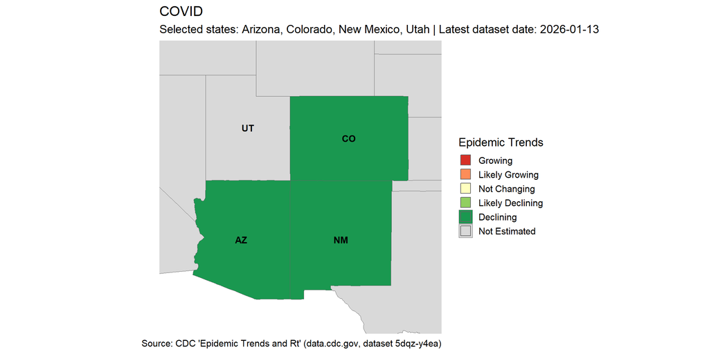

#### INFLUENZA

The current flu epidemic trend (based on data reported through 1/13/2026) is **declining** for Colorado, and New Mexico, is **not changing** for Arizona, and is not currently estimated for Utah. The weekly percentage of ED visits diagnosed with flu was **high** for Colorado, **moderate** for New Mexico & Utah, and **low** for Arizona.

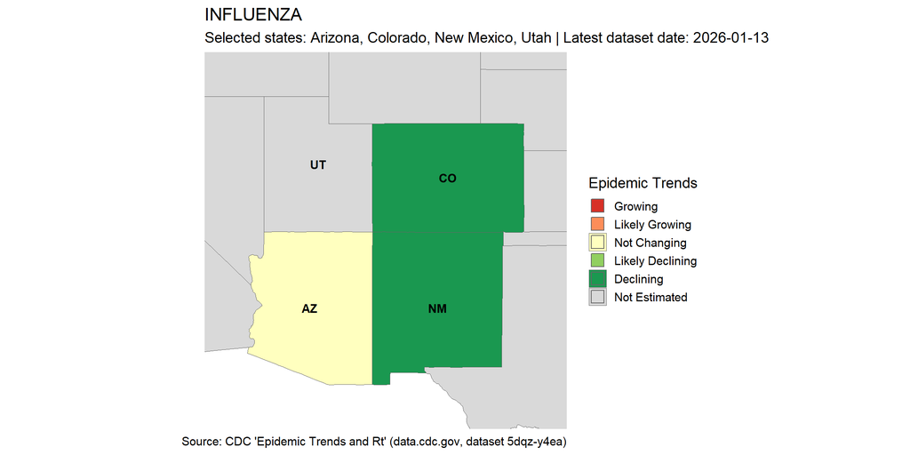

#### RSV

The current RSV epidemic trend (based on data reported through 1/13/2026) is **growing** for Colorado, **likely growing** for Arizona and New Mexico, and is not currently estimated for Utah. The weekly percentage of ED visits diagnosed with RSV was **low** for Arizona, Colorado, New Mexico, and Utah.

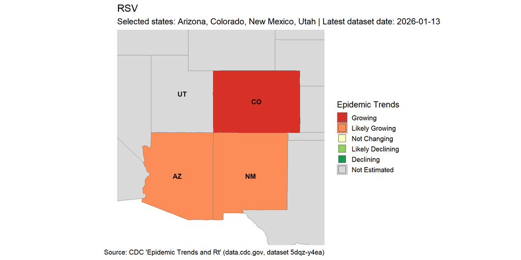

# Hospital Admissions by Disease

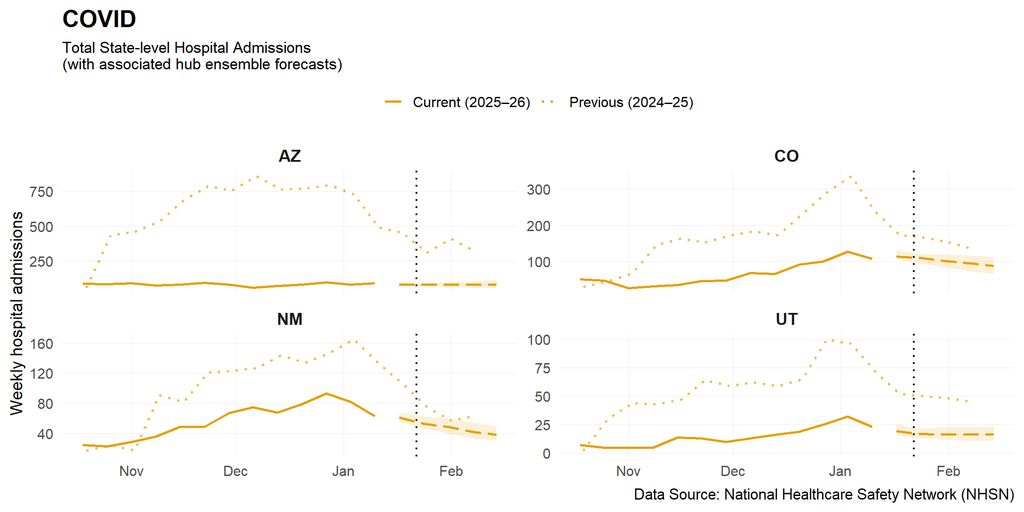

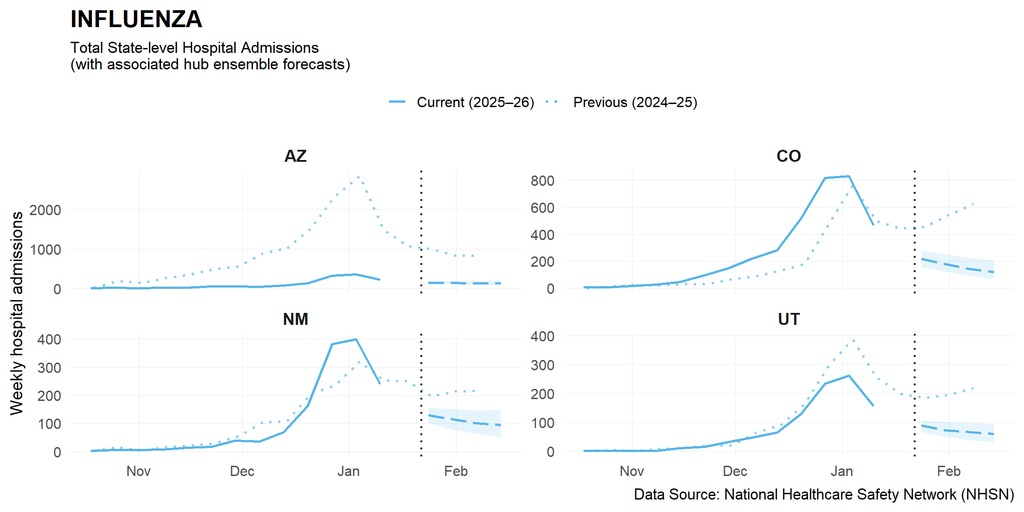

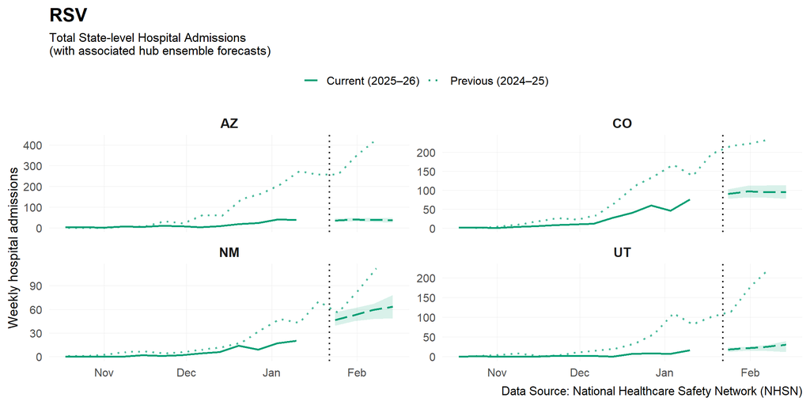

- This figure shows trends in hospitalizations based on data from the National Healthcare Safety Network (NHSN). Total number of weekly hospital admissions per disease are reported and each state sub-chart has a different Y-axis scale. Hospitalizations represent an estimate of the burden of severe disease and impact on the on healthcare system for each virus. Data from the previous season, represented with dotted lines, are also shown for comparison. The dashed black vertical line represents the current report date, but the most updated available data may not be as recent.  
  **Forecasts:**  
  In addition, we have included the most recent hub ensemble forecasts from each of the corresponding collaborative hubs: COVID-19 Forecast Hub, FluSight Forecast Hub, and RSV Forecast Hub. The hub ensembles are an average of each of the contributed models to the hub, where the dashed lines show the median estimated hospitalizations for the upcoming 1-4 weeks, and the shaded region indicates the 95% prediction intervals. Hub ensembles tend to be robust, as they incorporate insight from numerous teams and models.

# Percent of Emergency Department Visits by Disease

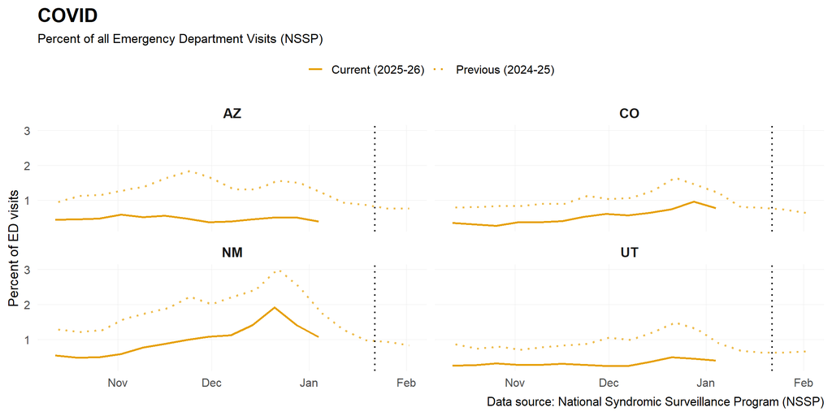

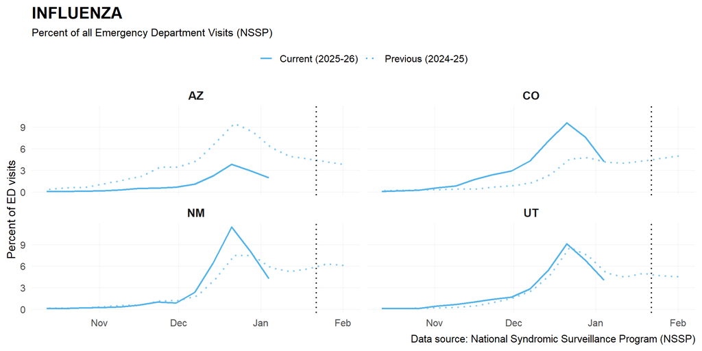

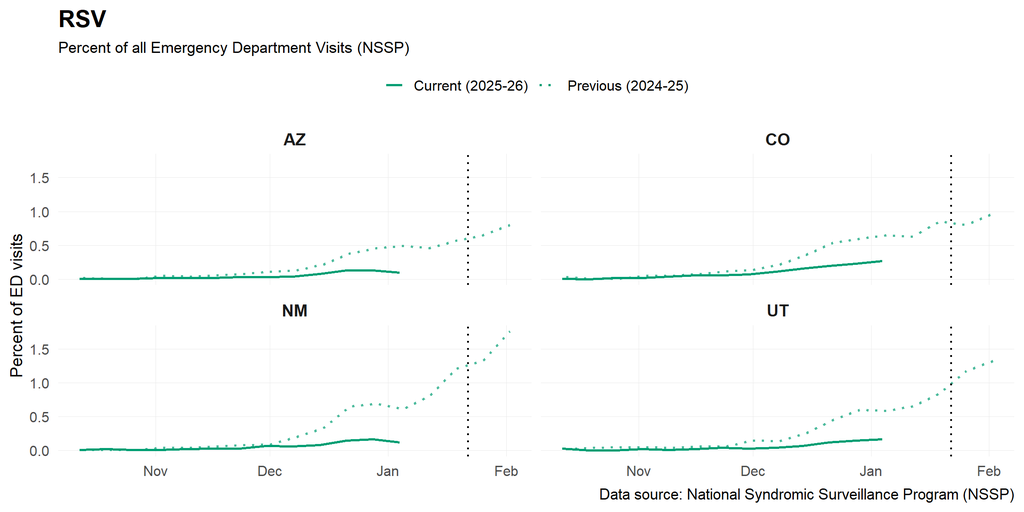

- This figure shows the state-level trends in the impact of respiratory virus activity on emergency department (ED) visits based on National Syndromic Surveillance Program (NSSP) data. The broad coverage of this emergency department sample helps to provide reasonable estimates of how much symptomatic illness each virus is causing in each state. The percentage of visits for each disease out of all ED visits is shown to allow comparability across time and across states despite different overall ED visit volume. Data from the previous season, represented with dotted lines, are also shown for comparison. The dashed black vertical line represents the current report date, but the most updated available data may not be as recent.  
  **Forecasts:**  
  Forecasts are not yet available for emergency department visits.

# Vaccination Coverage by Disease

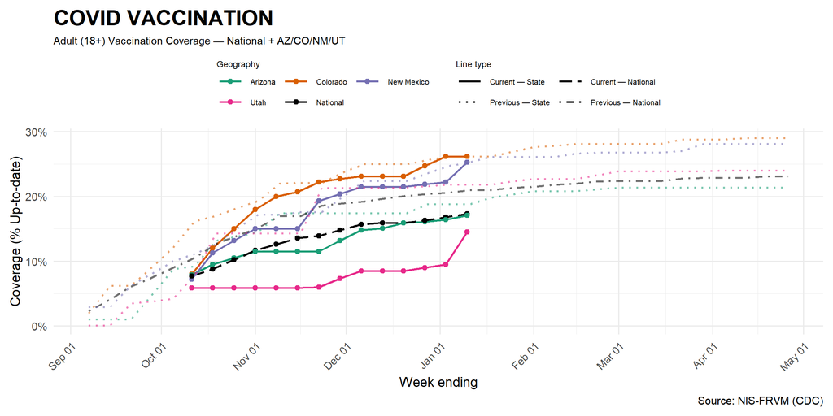

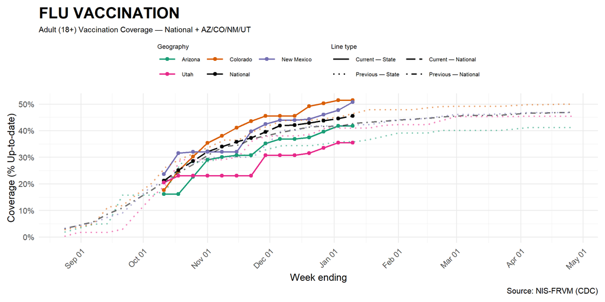

[figure not shown]

- These figures show national and state-level trends in vaccination coverage, representing percentage of the (age-specific) population ‘up-to-date’ for vaccination against COVID-19, flu, or RSV based on National Immunization Survey Fall Respiratory Virus Module (NIS-FRVM, previously called the Adult COVID Module or NIS-ACM) data. Data are shown for the 2025-2026 respiratory virus season, beginning October 2025, and for the previous 2024-2025 season (low-opacity, dotted lines). NIS-FRVM estimates are derived from self-report data obtained through phone surveys and may differ from estimates based on other data sources. In addition to random error associated with taking a sample, NIS-FRVM data are subject to errors resulting from incomplete sample frame, selection bias, and errors in self-reported vaccination status. Estimates are weighted to selected sociodemographic characteristics of the U.S. population to reduce possible bias from incomplete sample frame and selection bias. Visit [National Immunization Survey](https://www.cdc.gov/nis/about/index.html) for more information on survey methodology.  
  Coverage for COVID-19 and flu is shown for all individuals over 18, while RSV vaccination is shown for adults 50 years and older. State-specific estimates for pediatric RSV vaccination coverage are not available at this time. Current CDC adult RSV vaccination recommendations are for a single dose of RSV vaccine for all adults 75 years and older and adults 50–74 years who are at increased risk for severe RSV disease. RSV vaccination coverage estimates for seasons before the 2025-2026 are not available at this time.

**Current Situation (latest available week)**

| State | Virus | Latest ED % of visits | Latest Hosp Admissions (wk) |
| --- | --- | --- | --- |
| Arizona | COVID | 0.4% | 90 |
| Arizona | INFLUENZA | 2.0% | 219 |
| Arizona | RSV | 0.1% | 39 |
| Colorado | COVID | 0.8% | 108 |
| Colorado | INFLUENZA | 4.2% | 465 |
| Colorado | RSV | 0.3% | 76 |
| New Mexico | COVID | 1.1% | 63 |
| New Mexico | INFLUENZA | 4.3% | 239 |
| New Mexico | RSV | 0.1% | 20 |
| Utah | COVID | 0.4% | 23 |
| Utah | INFLUENZA | 4.1% | 157 |
| Utah | RSV | 0.2% | 16 |

Latest hosp: 2026-01-10; latest ED: 2026-01-04